# Reproducible Research: Peer Assessment 1

## Loading and preprocessing the data

- First we load necessary libraries:

```r
# suppress library loading warnings
library(ggplot2, quietly=T, warn.conflicts=F)
library(Hmisc, quietly=T, warn.conflicts=F)
library(dplyr, quietly=T, warn.conflicts=F)
```

- Next we unzip the **activity.zip** file if necessary and then load **activity.csv** into a dataframe. Note: please change the working directory to one containing the file on your computer.

```r
setwd("~/Documents/coursera/reproducible data/RepData_PeerAssessment1")
if (!file.exists("activity.csv")) {
    unzip("activity.zip")
}
df <- csv.get("activity.csv")
```

## Histogram of Total Number of Steps per Day

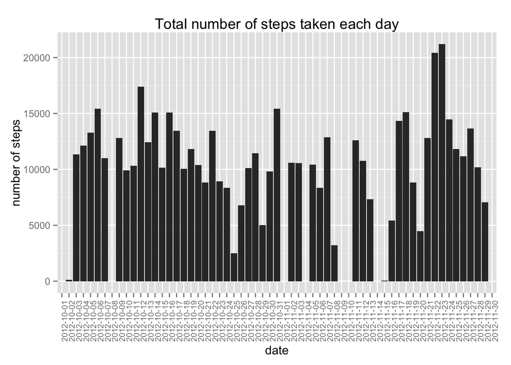

```r
dfm <- df %>% group_by(date)  %>%
    summarise(daily_total = sum(steps, na.rm=T),
              daily_mean = mean(steps, na.rm=T),
              daily_median = median(steps, na.rm=T),
              daily_NA = sum(is.na(steps))
              )

g <- ggplot(dfm, aes(x=date,y=daily_total))
g <- g + geom_bar(stat="identity")
g <- g + geom_bar(width=0.5, fill="white", color="black") + labs(x = "date", y = "number of steps", title = "Total number of steps taken each day")
g <- g + theme(axis.text.x = element_text(angle = 90, hjust = 1, size = 8,
   colour = "grey50"))
g
```

## Daily Means and Medians of Steps Taken

```r
dfm %>% select(date, daily_mean, daily_median)
```

```
## Source: local data frame [61 x 3]
##
##          date daily_mean daily_median
## 1  2012-10-01        NaN           NA
## 2  2012-10-02     0.4375            0
## 3  2012-10-03    39.4167            0
## 4  2012-10-04    42.0694            0
## 5  2012-10-05    46.1597            0
## 6  2012-10-06    53.5417            0
## 7  2012-10-07    38.2465            0
## 8  2012-10-08        NaN           NA
## 9  2012-10-09    44.4826            0
## 10 2012-10-10    34.3750            0
## 11 2012-10-11    35.7778            0
## 12 2012-10-12    60.3542            0
```

[output cut: 49 more lines]

## What is the average daily activity pattern?

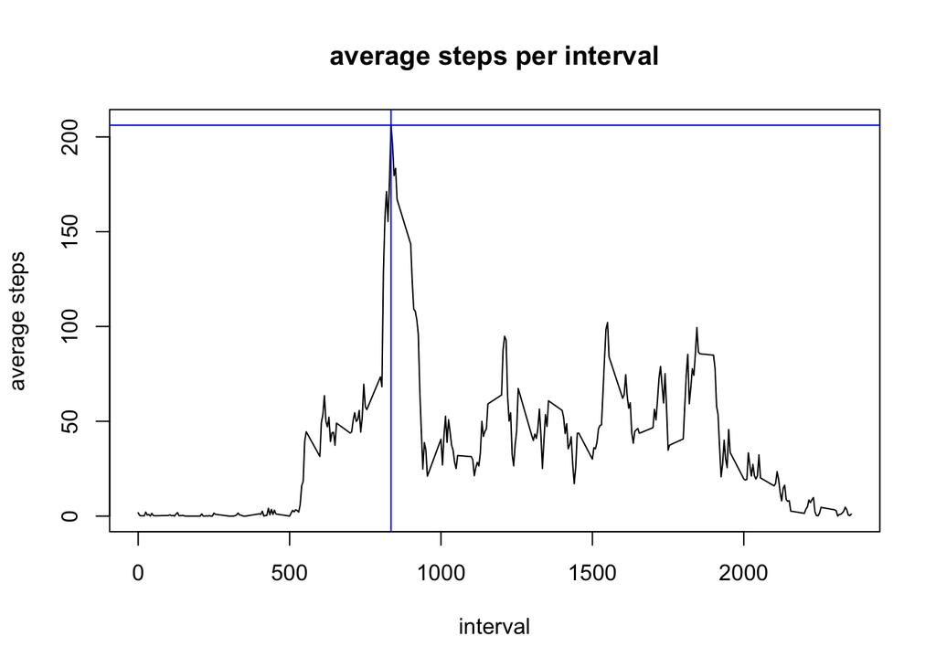

```r
df5 <- df %>%
    group_by(interval)  %>%
    summarise( interval_mean = mean(steps, na.rm=T))

plot(df5$interval,df5$interval_mean,type = 'l',xlab="interval", ylab="average steps", main="average steps per interval")
max_int <- df5[df5$interval_mean == max(df5$interval_mean),]
abline(v=max_int$interval,h=max_int$interval_mean, col="blue")
```

- The interval with the maximum average steps is 835 with a value of 206.2.

## Imputing missing values

We impute values for the NAs by replacing the missing **step** value the interval mean as calculated above in the variable **df5**. The dataframes **df** and **df5** are merged using the **interval** column and then the missing **step** values are replaced with the interval mean values from **df5**.

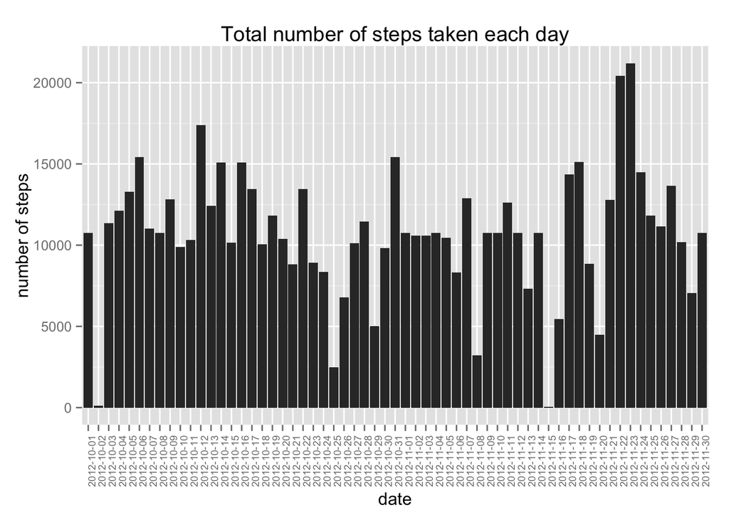

```r
df_av_int <- merge(x=df, y=df5, by="interval", all=T ) %>%
    mutate(steps = ifelse( is.na(steps), interval_mean, steps)) %>%
    select(- interval_mean)
#df_nona will have the total steps per date after replacing NA step values
# to the average steps of the interval.
df_nona <- df_av_int %>%
    group_by(date) %>%
    summarise(daily_total=sum(steps, na.rm = T),
              daily_mean=mean(steps, na.rm = T),
              daily_median=median(steps, na.rm = T))


#produce graphs
g <- ggplot(df_nona, aes(x=date,y=daily_total))
g <- g + geom_bar(stat="identity")
g <- g + geom_bar(width=0.5, fill="white", color="black") + labs(x = "date", y = "number of steps", title = "Total number of steps taken each day")
g <- g + theme(axis.text.x = element_text(angle = 90, hjust = 0, size = 7,
   colour = "grey50"))
g
```

- There are a total 2304 NA values for the **steps** variable.
- the variable **df_av_int** contains the new data with NA’s replaced with the mean for the interval.
- With the NA values replaced we get the following means and medians:

```r
df_nona %>% select(date, daily_mean, daily_median)
```

```
## Source: local data frame [61 x 3]
##
##          date daily_mean daily_median
## 1  2012-10-01    37.3826        34.11
## 2  2012-10-02     0.4375         0.00
## 3  2012-10-03    39.4167         0.00
## 4  2012-10-04    42.0694         0.00
## 5  2012-10-05    46.1597         0.00
## 6  2012-10-06    53.5417         0.00
## 7  2012-10-07    38.2465         0.00
## 8  2012-10-08    37.3826        34.11
## 9  2012-10-09    44.4826         0.00
## 10 2012-10-10    34.3750         0.00
## 11 2012-10-11    35.7778         0.00
## 12 2012-10-12    60.3542         0.00
```

[output cut: 49 more lines]

### Observations on the effect of substitutions on the data set

- Given that a day that had any NA’s, also had all NA’s, or no data at all, one could not calculate a mean or median for such a day.
- The difference between the data having NA’s and the data having substitutions are that the former data set has more days with 0 steps as the sum of an empty data set is zero. However, in the latter set, the median and mean exist for the previously NA days.
- The numerical difference between the datasets with and without substitions are shown below:

```r
df_merge = merge(x = dfm, y=df_nona, by="date",all=TRUE)

df_diff <- df_merge %>%
     select(date,
            median.NA = daily_median.x,
            median.sub = daily_median.y,
            mean.NA = daily_mean.x,
            mean.sub = daily_mean.y ) %>%
    mutate(diff.median = median.NA - median.sub,
            diff.mean = mean.NA - mean.sub)
df_diff
```

```
##          date median.NA median.sub mean.NA mean.sub diff.median diff.mean
## 1  2012-10-01        NA      34.11     NaN  37.3826          NA       NaN
## 2  2012-10-02         0       0.00  0.4375   0.4375           0         0
## 3  2012-10-03         0       0.00 39.4167  39.4167           0         0
## 4  2012-10-04         0       0.00 42.0694  42.0694           0         0
## 5  2012-10-05         0       0.00 46.1597  46.1597           0         0
## 6  2012-10-06         0       0.00 53.5417  53.5417           0         0
## 7  2012-10-07         0       0.00 38.2465  38.2465           0         0
## 8  2012-10-08        NA      34.11     NaN  37.3826          NA       NaN
## 9  2012-10-09         0       0.00 44.4826  44.4826           0         0
## 10 2012-10-10         0       0.00 34.3750  34.3750           0         0
## 11 2012-10-11         0       0.00 35.7778  35.7778           0         0
## 12 2012-10-12         0       0.00 60.3542  60.3542           0         0
## 13 2012-10-13         0       0.00 43.1458  43.1458           0         0
## 14 2012-10-14         0       0.00 52.4236  52.4236           0         0
```

[output cut: 47 more lines]

## Are there differences in activity patterns between weekdays and weekends?

The following graphics seem to suggest that there is more activity during the morning for weekdays, but more activity throughout the day during the weekend.

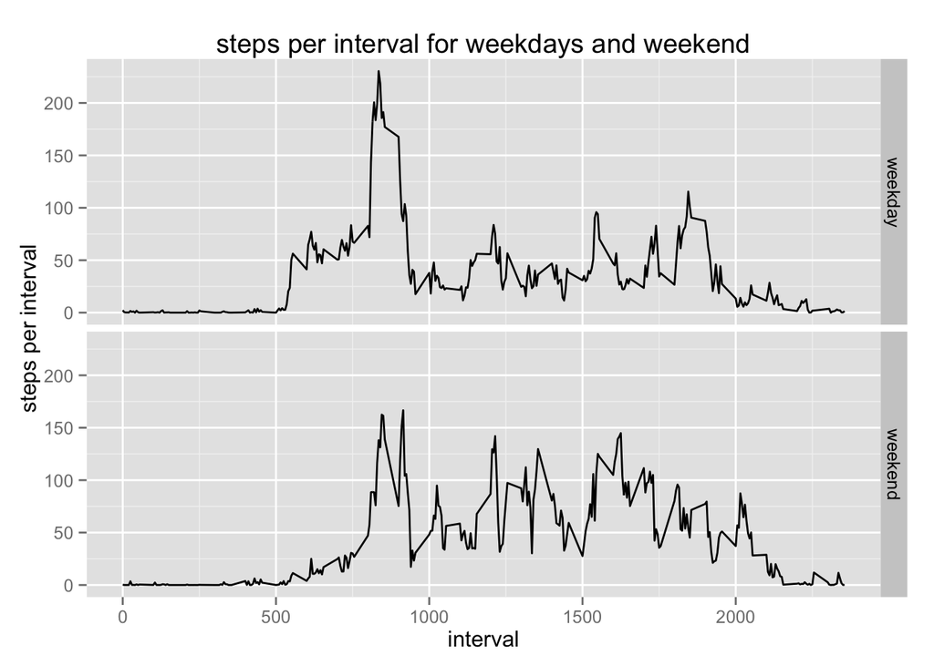

```r
# Important: use ifelse for vectorized operations !
week_factor <- function ( aDate ) {
    weekday = weekdays(as.Date(aDate))
    ifelse (weekday %in% c("Saturday","Sunday"), "weekend","weekday")
}

df_wd <- df_av_int %>%
    mutate(weekend = factor(week_factor(date))) %>%
    group_by(weekend,interval) %>%
    summarise(av_steps=mean(steps, na.rm=T))


qplot( interval, av_steps, data=df_wd, geom="line", facets = weekend ~ ., ylab="steps per interval", main="steps per interval for weekdays and weekend")
```